# Cluster Analysis in Integrated Data

hongc2@ccf.org

1/16/2020

### Setup

Let us setup the experiment by loading the previous R environment files and R libraries if not exist.

```r
library(data.table)
library(ggplot2)
library(Seurat)

load('out/01_immune_combined.rd') #immune.combined
```

### Identify conserved cell type markers

To identify canonical cell type marker genes that are conserved across conditions, we provide the `FindConservedMarkers` function. This function performs differential gene expression testing for each dataset/group and combines the p-values using meta-analysis methods from the `MetaDE` R package. For example, we can calculate the genes that are conserved markers irrespective of stimulation condition in a cluster labeled by ‘NK’ cells.

```r
DefaultAssay(immune.combined) <- "RNA"
Idents(immune.combined) <- "seurat_annotations"

message("This run will take 5+ min ...")
```

```
## This run will take 5+ min ...
```

```r
nk.markers <- FindConservedMarkers(immune.combined, ident.1 = "NK", grouping.var = "stim", verbose = FALSE) #default slot: 'data'
head(nk.markers)
```

```
##        CTRL_p_val CTRL_avg_logFC CTRL_pct.1 CTRL_pct.2 CTRL_p_val_adj
## GNLY            0       4.186117      0.943      0.046              0
## NKG7            0       3.164712      0.953      0.085              0
## GZMB            0       2.915692      0.839      0.044              0
## CLIC3           0       2.407695      0.601      0.024              0
## FGFBP2          0       2.241968      0.500      0.021              0
## CTSW            0       2.088278      0.537      0.030              0
##           STIM_p_val STIM_avg_logFC STIM_pct.1 STIM_pct.2 STIM_p_val_adj
## GNLY    0.000000e+00       4.066429      0.956      0.059   0.000000e+00
## NKG7    0.000000e+00       2.904602      0.950      0.081   0.000000e+00
## GZMB    0.000000e+00       3.128167      0.897      0.060   0.000000e+00
## CLIC3   0.000000e+00       2.460388      0.623      0.031   0.000000e+00
## FGFBP2 1.674159e-159       1.485116      0.259      0.016  2.352696e-155
## CTSW    0.000000e+00       2.175186      0.592      0.035   0.000000e+00
##             max_pval minimump_p_val
## GNLY    0.000000e+00              0
## NKG7    0.000000e+00              0
## GZMB    0.000000e+00              0
## CLIC3   0.000000e+00              0
## FGFBP2 1.674159e-159              0
## CTSW    0.000000e+00              0
```

Furthermore, we can explore the following marker genes for each cell type to verify if the clusters have specific cell types.

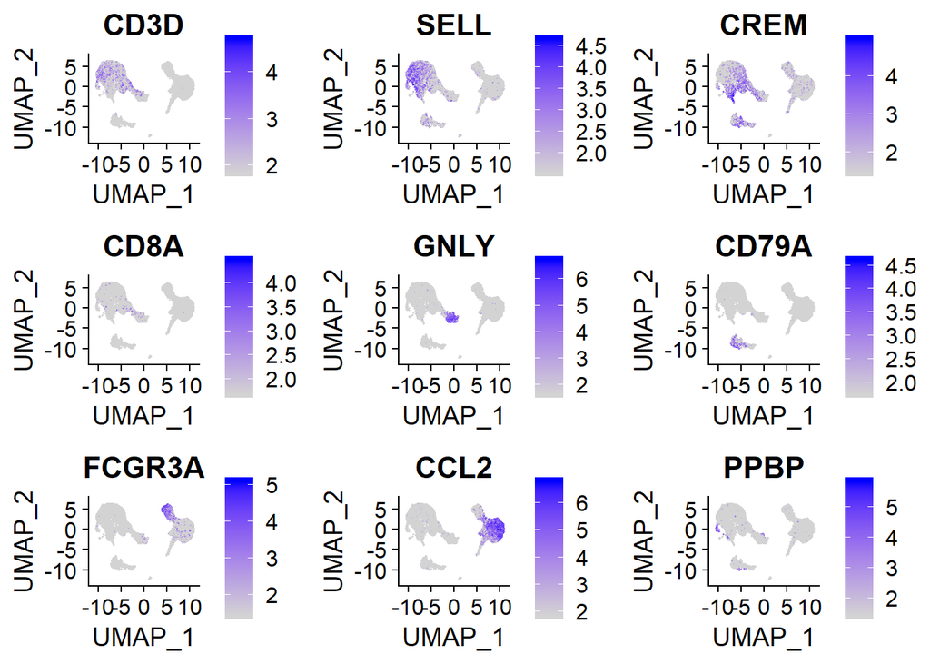

```r
marker_genes <- c("CD3D", "SELL", "CREM", "CD8A", "GNLY", "CD79A", "FCGR3A", "CCL2", "PPBP")

FeaturePlot(immune.combined, features = marker_genes, min.cutoff = "q9")
```

The `DotPlot` function with the `split.by` can be useful for viewing conserved cell type markers across conditions, showing both the expression level and the percentage of cells in a cluster expressing any given gene. Here we plot 2-3 strong marker genes for each of our 13 clusters.

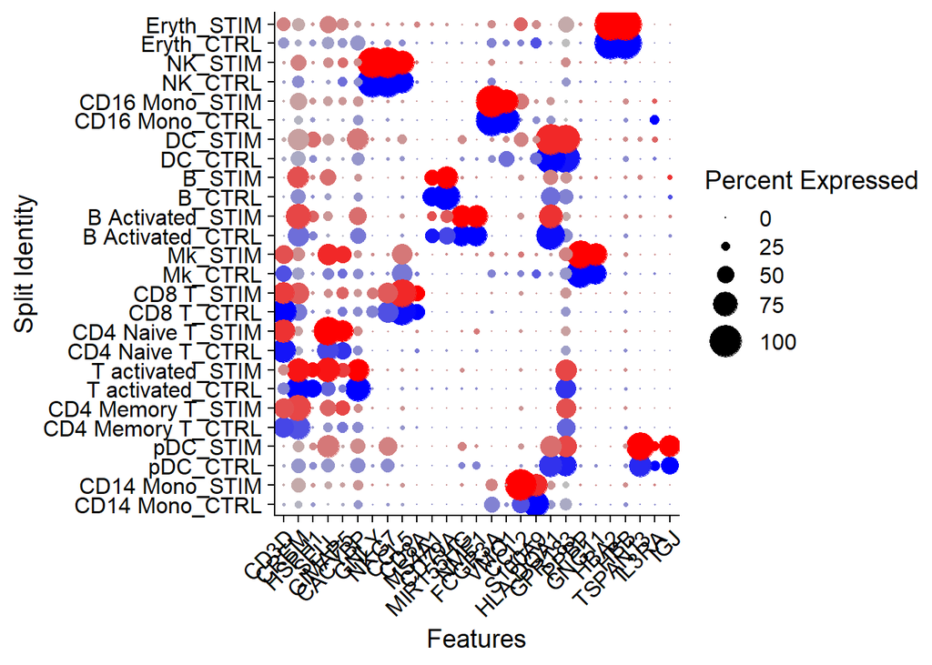

```r
markers.to.plot <- c("CD3D", "CREM", "HSPH1", "SELL", "GIMAP5", "CACYBP", "GNLY", "NKG7", "CCL5", "CD8A", "MS4A1", "CD79A", "MIR155HG", "NME1", "FCGR3A", "VMO1", "CCL2", "S100A9", "HLA-DQA1", "GPR183", "PPBP", "GNG11", "HBA2", "HBB", "TSPAN13", "IL3RA", "IGJ")

DotPlot(immune.combined,
        features = rev(markers.to.plot),
        cols = c("blue", "red"),
        dot.scale = 8,
        split.by = "stim") + RotatedAxis()
```

Let us save the R variable so that we can continue to work.

```r
save(immune.combined, file = 'out/02_immune_cons.rd',compress = TRUE)
```

### At this point, you should know

- When conserved gene are useful?
- In Seurat object,
  - What is assay?
  - What is slot?
  - Why there are multiple slots?